# Air Quality Index Prediction

Kailash Natarajan

23/10/2020

# Air Quality Index Prediction

In this project, we will be predicting CO, SO2, NO2 index values for the next 5 days based on the previous 30 days of data. This prediction will be only for Chennai city. The file with data collected in 2020 for all major cities is available at the link below. We will be extracting data for Chennai city from that.

```
[1] "https://aqicn.org/data-platform/covid19/report/18248-4d650f91/2020"
```

# Download the file automatically

```r
download.file("https://aqicn.org/data-platform/covid19/report/18248-4d650f91/2020",
            destfile = "waqi-covid19-airqualitydata-2020.csv")
```

# Reading the file

Read the file into a variable to make use of it.

```r
#Reading the downloaded .csv file properly.
aqi<-read.csv(file='waqi-covid19-airqualitydata-2020.csv',sep=",",skip=4,header=TRUE)
```

# Subset the required data

Our dataset contains air quality index data for every major city in the world. But our focus is only on Chennai and we make our prediction only for that. So we extract the values only for Chennai.

```r
#Subset data pertaining to chennai only
chennai<-aqi[aqi[,3]=="Chennai",]
chennai<-as.data.frame(chennai)
```

# Sorting the data

We want our data to be sorted by date because our prediction model will depend on it.

```r
#sorting the data based on date
chennai<-chennai[order(chennai$Date),]
```

# Subset CO, SO2, NO2

The air quality index dataset contains various parameters of measurement. We will use only CO,SO2 and NO2 parameters for the sake of this project.

```r
#Subset data that for CO, SO2,NO2 only
ch_co<-chennai[chennai[,4]=="co",c(1,3,4,6,7,8)]
ch_so2<-chennai[chennai[,4]=="so2",c(1,3,4,6,7,8)]
ch_no2<-chennai[chennai[,4]=="no2",c(1,3,4,6,7,8)]
```

# Getting to know the data

This will show us the head of the data for each of co, so2 and no2. This will make it clear for the reader to understand the data.

### Contents of CO dataset:

```r
head(ch_co)
```

|  | Date | City | Specie | min | max | median |
| --- | --- | --- | --- | --- | --- | --- |
| 281394 | 2019-12-30 | Chennai | co | 2.6 | 10.9 | 4.0 |
| 281426 | 2019-12-31 | Chennai | co | 2.5 | 15.7 | 3.9 |
| 281345 | 2020-01-01 | Chennai | co | 2.1 | 9.7 | 3.9 |
| 281574 | 2020-01-02 | Chennai | co | 2.7 | 14.0 | 4.0 |
| 281455 | 2020-01-03 | Chennai | co | 2.6 | 86.3 | 3.9 |
| 281557 | 2020-01-04 | Chennai | co | 1.5 | 9.2 | 4.1 |

```r
dim(ch_co)
```

```
## [1] 299   6
```

### Contents of SO2 dataset:

```r
head(ch_so2)
```

|  | Date | City | Specie | min | max | median |
| --- | --- | --- | --- | --- | --- | --- |
| 279478 | 2019-12-30 | Chennai | so2 | 0.2 | 58.3 | 2.6 |
| 279317 | 2019-12-31 | Chennai | so2 | 0.4 | 58.2 | 2.6 |
| 279327 | 2020-01-01 | Chennai | so2 | 0.2 | 30.3 | 2.8 |
| 279398 | 2020-01-02 | Chennai | so2 | 0.4 | 9.6 | 2.8 |
| 279439 | 2020-01-03 | Chennai | so2 | 0.1 | 21.7 | 3.2 |
| 279279 | 2020-01-04 | Chennai | so2 | 0.9 | 10.3 | 3.4 |

```r
dim(ch_so2)
```

```
## [1] 299   6
```

### Contents of NO2 dataset:

```r
head(ch_no2)
```

|  | Date | City | Specie | min | max | median |
| --- | --- | --- | --- | --- | --- | --- |
| 281770 | 2019-12-30 | Chennai | no2 | 0.3 | 16.0 | 6.8 |
| 281828 | 2019-12-31 | Chennai | no2 | 0.3 | 21.0 | 7.0 |
| 281886 | 2020-01-01 | Chennai | no2 | 0.3 | 15.3 | 3.9 |
| 281685 | 2020-01-02 | Chennai | no2 | 0.1 | 11.3 | 5.1 |
| 281864 | 2020-01-03 | Chennai | no2 | 0.1 | 20.9 | 2.6 |
| 281821 | 2020-01-04 | Chennai | no2 | 0.1 | 14.0 | 3.1 |

```r
dim(ch_no2)
```

```
## [1] 299   6
```

# Retrieving 30 days of data and making a Regression Line

This piece of code subsets the last 30 days of data for use. These air quality parameters are hugely impacted by external weather and seasons. So it makes sense to include only the recent readings, and thus reduce the impact of weather and seasons on our prediction.

It also does the linear modeling for the prediction. This will result in a regression line.

```r
#Subsetting 30 days of data and developing regression line
start=dim(ch_co)[1]-29
end=dim(ch_co)[1]
co<-data.frame(
  x=1:30,
  lo=ch_co[start:end,4],
  hi=ch_co[start:end,5],
  med=ch_co[start:end,6]
)
so2<-data.frame(
  x=1:30,
  lo=ch_so2[start:end,4],
  hi=ch_so2[start:end,5],
  med=ch_so2[start:end,6]
)
no2<-data.frame(
  x=1:30,
  lo=ch_no2[start:end,4],
  hi=ch_no2[start:end,5],
  med=ch_no2[start:end,6]
)

co_lo_line=lm(lo~x,data=co)
co_hi_line=lm(hi~x,data=co)
co_med_line=lm(med~x,data=co)

so2_lo_line=lm(lo~x,data=so2)
so2_hi_line=lm(hi~x,data=so2)
so2_med_line=lm(med~x,data=so2)

no2_lo_line=lm(lo~x,data=no2)
no2_hi_line=lm(hi~x,data=no2)
no2_med_line=lm(med~x,data=no2)
```

# Linear Modelling outcomes

```r
co_lo_line
```

```
##
## Call:
## lm(formula = lo ~ x, data = co)
##
## Coefficients:
## (Intercept)            x
##     0.66345     -0.00861
```

```r
co_med_line
```

```
##
## Call:
## lm(formula = med ~ x, data = co)
##
## Coefficients:
## (Intercept)            x
##     4.40713      0.04814
```

```r
co_hi_line
```

```
##
## Call:
## lm(formula = hi ~ x, data = co)
##
## Coefficients:
## (Intercept)            x
##     11.8929       0.4899
```

```r
so2_lo_line
```

```
##
## Call:
## lm(formula = lo ~ x, data = so2)
##
## Coefficients:
## (Intercept)            x
##    0.751724     0.001824
```

```r
so2_med_line
```

```
##
## Call:
## lm(formula = med ~ x, data = so2)
##
## Coefficients:
## (Intercept)            x
##     2.08161      0.02269
```

```r
so2_hi_line
```

```
##
## Call:
## lm(formula = hi ~ x, data = so2)
##
## Coefficients:
## (Intercept)            x
##     18.8600      -0.3006
```

```r
no2_lo_line
```

```
##
## Call:
## lm(formula = lo ~ x, data = no2)
##
## Coefficients:
## (Intercept)            x
##     1.32345      0.02816
```

```r
no2_med_line
```

```
##
## Call:
## lm(formula = med ~ x, data = no2)
##
## Coefficients:
## (Intercept)            x
##     4.26782      0.03971
```

```r
no2_hi_line
```

```
##
## Call:
## lm(formula = hi ~ x, data = no2)
##
## Coefficients:
## (Intercept)            x
##     27.6747      -0.3807
```

```r
head(co)
```

|  | x | lo | hi | med |
| --- | --- | --- | --- | --- |
| 1 | 1 | 0.9 | 10.3 | 4.3 |
| 2 | 2 | 0.6 | 9.0 | 4.9 |
| 3 | 3 | 0.1 | 18.2 | 4.6 |
| 4 | 4 | 0.6 | 17.2 | 5.4 |
| 5 | 5 | 0.7 | 15.6 | 4.5 |
| 6 | 6 | 0.5 | 9.6 | 3.4 |

```r
head(so2)
```

|  | x | lo | hi | med |
| --- | --- | --- | --- | --- |
| 1 | 1 | 0.9 | 9.9 | 1.7 |
| 2 | 2 | 1.0 | 11.4 | 2.4 |
| 3 | 3 | 0.2 | 32.4 | 2.0 |
| 4 | 4 | 0.9 | 16.3 | 1.7 |
| 5 | 5 | 1.0 | 18.2 | 2.0 |
| 6 | 6 | 0.7 | 16.5 | 3.0 |

```r
head(no2)
```

|  | x | lo | hi | med |
| --- | --- | --- | --- | --- |
| 1 | 1 | 0.6 | 9.2 | 3.9 |
| 2 | 2 | 1.8 | 12.3 | 4.2 |
| 3 | 3 | 1.8 | 25.0 | 4.9 |
| 4 | 4 | 1.1 | 22.5 | 4.2 |
| 5 | 5 | 0.8 | 19.2 | 4.6 |
| 6 | 6 | 0.7 | 25.4 | 4.4 |

# Plotting the data

This code is added to plot each of the index separately, to help us visualize the data given. We also include the regression line with the points in the plot to get an idea and visualise the trend.

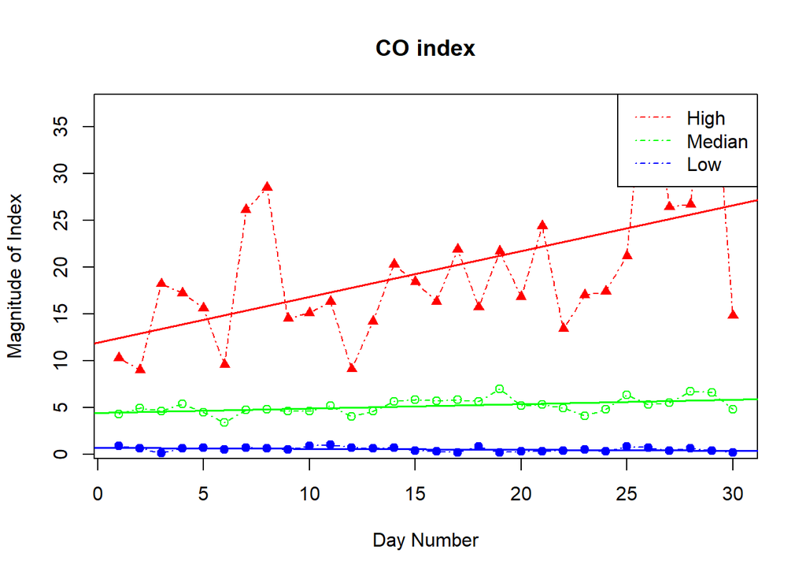

```r
#Plot for CO
##30 days of data
xval=1:30
#This is to cover 95% of high values. We don't want to plot all the points as
#the low values may become less significant in the plot
yval=seq(1,as.integer(quantile(co$hi,probs=0.95)[[1]])+1,length=30)
##Generating random values to open a blank plot window
plot(xval,yval,type="n",xlab="Day Number",ylab="Magnitude of Index",main="CO index")
points(co$hi,col="red",type="o",pch=17,lty=4)
points(co$lo,col="blue",type="o",pch=19,lty=4)
points(co$med,col="green",type="o",pch=21,lty=4)
legend("topright",col=c("red","green","blue"),legend=c("High","Median","Low"),
       lty=c(4,4,4),bg="white")
abline(co_lo_line,col="blue",lwd=1.5)
abline(co_med_line,col="green",lwd=1.5)
abline(co_hi_line,col="red",lwd=1.5)
```

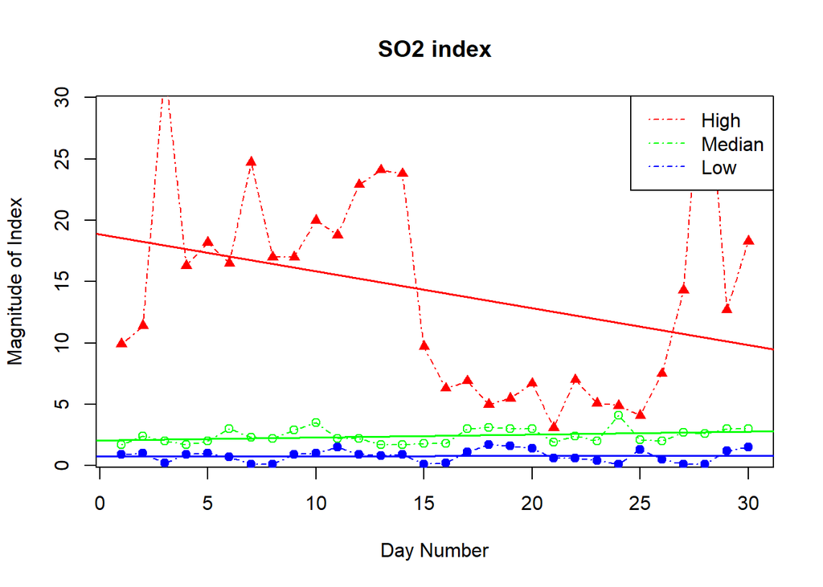

```r
#Plot for SO2
##30 days of data
xval=1:30
#This is to cover 95% of high values. We don't want to plot all
#the points as the low values may become less significant in the plot
yval=seq(1,as.integer(quantile(so2$hi,probs=0.95)[[1]])+1,length=30)
##Generating random values to open a blank plot window
plot(xval,yval,type="n",xlab="Day Number",ylab="Magnitude of Index",main="SO2 index")
points(so2$hi,col="red",type="o",pch=17,lty=4)
points(so2$lo,col="blue",type="o",pch=19,lty=4)
points(so2$med,col="green",type="o",pch=21,lty=4)
legend("topright",col=c("red","green","blue"),legend=c("High","Median","Low"),
       lty=c(4,4,4),bg="white")
abline(so2_lo_line,col="blue",lwd=1.5)
abline(so2_med_line,col="green",lwd=1.5)
abline(so2_hi_line,col="red",lwd=1.5)
```

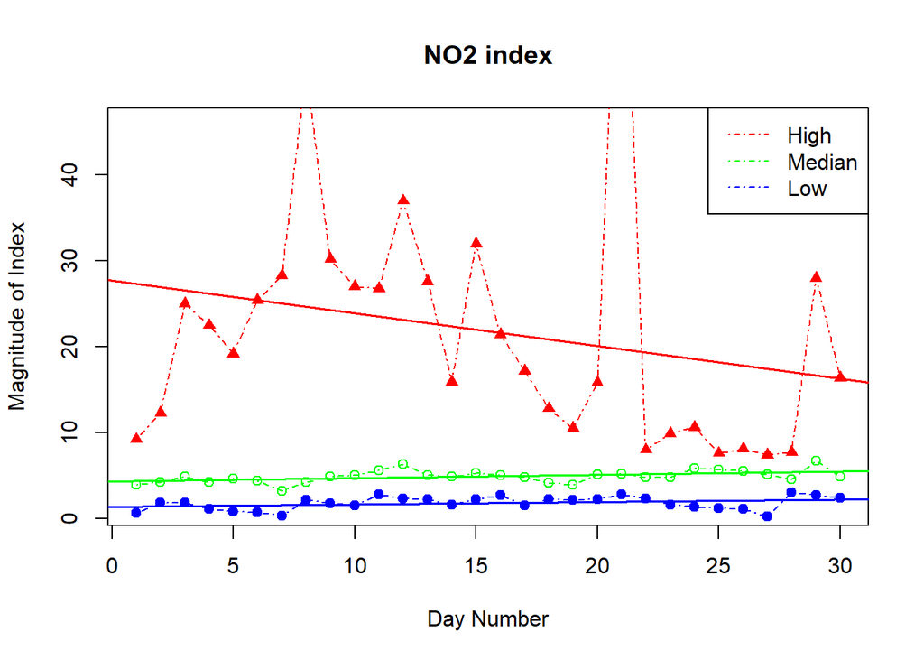

```r
#Plot for NO2
##30 days of data
xval=1:30
#This is to cover 95% of high values. We don't want to plot all the points as
#the low values may become less significant in the plot
yval=seq(1,as.integer(quantile(no2$hi,probs=0.95)[[1]])+1,length=30)
##Generating random values to open a blank plot window
plot(xval,yval,type="n",xlab="Day Number",ylab="Magnitude of Index",main="NO2 index")
points(no2$hi,col="red",type="o",pch=17,lty=4)
points(no2$lo,col="blue",type="o",pch=19,lty=4)
points(no2$med,col="green",type="o",pch=21,lty=4)
legend("topright",col=c("red","green","blue"),legend=c("High","Median","Low"),
       lty=c(4,4,4),bg="white")
abline(no2_lo_line,col="blue",lwd=1.5)
abline(no2_med_line,col="green",lwd=1.5)
abline(no2_hi_line,col="red",lwd=1.5)
```

# Analysis from plotting

From the plots, we can make some conclusions that:

-> Highest CO values are getting higher day by day.

-> Median CO values are on slightly increasing side. So we can conclude that CO is consistently increasing in Chennai.

-> Highest SO2 values are consistently decreasing, but the median is increasing. So, we cannot make a direct conclusion on SO2 emissions in Chennai.

-> NO2 highest values also seems to be on the decreasing side even if the median is increasing. So here also conclusions cannot be made directly.

# Prediction

This code will predict the next 5 days values for each of the 3 index which we chose. The printed output will be at the end.

```r
#equation of regression line
#5 days prediction

co_lo_pred=numeric()
co_hi_pred=numeric()
co_med_pred=numeric()
so2_lo_pred=numeric()
so2_hi_pred=numeric()
so2_med_pred=numeric()
no2_lo_pred=numeric()
no2_hi_pred=numeric()
no2_med_pred=numeric()

#co
for(i in 1:5){
co_lo_pred[i]=as.numeric(co_lo_line[[1]][2])*(i+30)+as.numeric(co_lo_line[[1]][1])
co_hi_pred[i]=as.numeric(co_hi_line[[1]][2])*(i+30)+as.numeric(co_hi_line[[1]][1])
co_med_pred[i]=as.numeric(co_med_line[[1]][2])*(i+30)+as.numeric(co_med_line[[1]][1])
}
#so2
for(i in 1:5){
so2_lo_pred[i]=as.numeric(so2_lo_line[[1]][2])*(i+30)+as.numeric(so2_lo_line[[1]][1])
so2_hi_pred[i]=as.numeric(so2_hi_line[[1]][2])*(i+30)+as.numeric(so2_hi_line[[1]][1])
so2_med_pred[i]=as.numeric(so2_med_line[[1]][2])*(i+30)+as.numeric(so2_med_line[[1]][1])
}

#no2
for(i in 1:5){
no2_lo_pred[i]=as.numeric(no2_lo_line[[1]][2])*(i+30)+as.numeric(no2_lo_line[[1]][1])
no2_hi_pred[i]=as.numeric(no2_hi_line[[1]][2])*(i+30)+as.numeric(no2_hi_line[[1]][1])
no2_med_pred[i]=as.numeric(no2_med_line[[1]][2])*(i+30)+as.numeric(no2_med_line[[1]][1])
}
pred_co=data.frame(
  lo=co_lo_pred,
  hi=co_hi_pred,
  med=co_med_pred
)
pred_so2=data.frame(
  lo=so2_lo_pred,
  hi=so2_hi_pred,
  med=so2_med_pred
)
pred_no2=data.frame(
  lo=no2_lo_pred,
  hi=no2_hi_pred,
  med=no2_med_pred
)
```

## Prediction values of CO for the next 5 days

```r
pred_co
```

| lo | hi | med |
| --- | --- | --- |
| 0.3965517 | 27.08046 | 5.899540 |
| 0.3879422 | 27.57038 | 5.947683 |
| 0.3793326 | 28.06030 | 5.995825 |
| 0.3707230 | 28.55023 | 6.043967 |
| 0.3621135 | 29.04015 | 6.092110 |

## Prediction values of SO2 for the next 5 days

```r
pred_so2
```

| lo | hi | med |
| --- | --- | --- |
| 0.8082759 | 9.540000 | 2.785057 |
| 0.8101001 | 9.239355 | 2.807749 |
| 0.8119244 | 8.938710 | 2.830441 |
| 0.8137486 | 8.638065 | 2.853133 |
| 0.8155729 | 8.337419 | 2.875825 |

## Prediction values of NO2 for the next 5 days

```r
pred_no2
```

| lo | hi | med |
| --- | --- | --- |
| 2.196552 | 15.87195 | 5.498851 |
| 2.224716 | 15.49122 | 5.538561 |
| 2.252881 | 15.11049 | 5.578272 |
| 2.281046 | 14.72975 | 5.617983 |
| 2.309210 | 14.34902 | 5.657694 |

# Accessing the markdown file containing the code to this project

The R-markdown file can be downloaded as zip by clicking on the link below:

```r
print("https://github.com/Kailash-Natarajan/Air-Quality-Index-Prediction/archive/gh-pages.zip")
```

```
## [1] "https://github.com/Kailash-Natarajan/Air-Quality-Index-Prediction/archive/gh-pages.zip"
```

The file can be open with R-studio and can be knit to HTML or PDF by clicking on Knit option.

The R-markdown file can also be viewed online as text by clicking on the link below:

```r
print("https://github.com/Kailash-Natarajan/Air-Quality-Index-Prediction/blob/gh-pages/R-lab-project-19bec1120.Rmd")
```

```
## [1] "https://github.com/Kailash-Natarajan/Air-Quality-Index-Prediction/blob/gh-pages/R-lab-project-19bec1120.Rmd"
```